# Principal Component Analysis Activity

INSOFE Lab Activity on PCA

23 Sep 2018

**NOTE** Before starting this assignment please remember to clear your environment, you can do that by running the following code chunk

```r
rm(list = ls(all=TRUE))
```

# Agenda

- Derive Principal Components (Principal Modes of Variation)
- Understand PCA from first principles
- Understand the Importance of Data Scaling in PCA
- Automated computation of the Principal Components
- Apply PCA for data complexity reduction

# Iris Data

**Data Description:**

- The data set contains 5 variables and 3 classes of 50 instances each, where each class refers to a type of iris plant.
- The variable names are self explanatory

## Understand the data

- Read in the data

```r
iris_data <- iris
```

- Get the structure and summary of the data
- The data has 5 attributes and 150 rows

```r
str(iris_data)
```

```
## 'data.frame':    150 obs. of  5 variables:
##  $ Sepal.Length: num  5.1 4.9 4.7 4.6 5 5.4 4.6 5 4.4 4.9 ...
##  $ Sepal.Width : num  3.5 3 3.2 3.1 3.6 3.9 3.4 3.4 2.9 3.1 ...
##  $ Petal.Length: num  1.4 1.4 1.3 1.5 1.4 1.7 1.4 1.5 1.4 1.5 ...
##  $ Petal.Width : num  0.2 0.2 0.2 0.2 0.2 0.4 0.3 0.2 0.2 0.1 ...
##  $ Species     : Factor w/ 3 levels "setosa","versicolor",..: 1 1 1 1 1 1 1 1 1 1 ...
```

```r
summary(iris_data)
```

```
##   Sepal.Length    Sepal.Width     Petal.Length    Petal.Width
##  Min.   :4.300   Min.   :2.000   Min.   :1.000   Min.   :0.100
##  1st Qu.:5.100   1st Qu.:2.800   1st Qu.:1.600   1st Qu.:0.300
##  Median :5.800   Median :3.000   Median :4.350   Median :1.300
##  Mean   :5.843   Mean   :3.057   Mean   :3.758   Mean   :1.199
##  3rd Qu.:6.400   3rd Qu.:3.300   3rd Qu.:5.100   3rd Qu.:1.800
##  Max.   :7.900   Max.   :4.400   Max.   :6.900   Max.   :2.500
##        Species
##  setosa    :50
##  versicolor:50
##  virginica :50
##
##
##
```

Running the multiclass classification model on the iris dataset

```r
library(nnet)

multinom_model = multinom(Species~., data = iris_data )
pred_results = multinom_model$fitted.values


actl_results = iris_data$Species


results = data.frame("pred_spec" = colnames(pred_results)[apply(pred_results,1,function(x) which(x==max(x)))],
                     "act_spec" = iris_data$Species)

table(results)
```

```
##             act_spec
## pred_spec    setosa versicolor virginica
##   setosa         50          0         0
##   versicolor      0         49         1
##   virginica       0          1        49
```

# Computing PCA from the first principles

## Linear Separability in the data

- Compute the variance of each variable in the dataset
- Plot the data across the two variables with the highest variance

```r
# Using lapply() function we apply the var() function on each of the variables excluding the target

lapply(iris_data[, -5], var)
```

```
## $Sepal.Length
## [1] 0.6856935
##
## $Sepal.Width
## [1] 0.1899794
##
## $Petal.Length
## [1] 3.116278
##
## $Petal.Width
## [1] 0.5810063
```

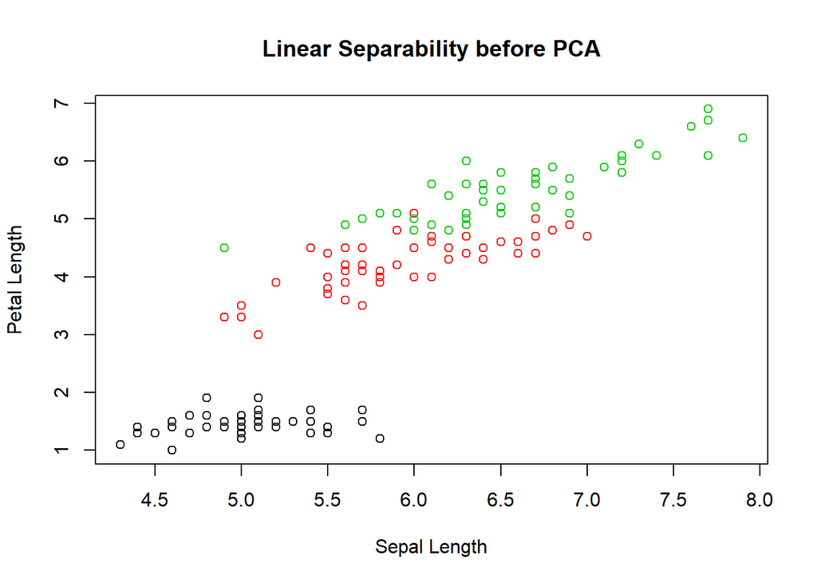

```r
# Plot the data points on the axes with the highest variances

plot(iris_data$Sepal.Length, iris_data$Petal.Length, col = iris_data$Species, xlab = "Sepal Length", ylab = "Petal Length",
    main = "Linear Separability before PCA")
```

- From the above plot it is visible that the data cannot be linearly separated by just using two axes, that too the ones with the highest variance

## Covariance Matrix

- Compute the covariance matrix of the dataset using the cov() function

```r
# don't get confused, cov(x,x) = var(x)

cov_mat <- cov(iris_data[ , -5])
```

- The covariance matrix is as follows

```r
print(cov_mat)
```

```
##              Sepal.Length Sepal.Width Petal.Length Petal.Width
## Sepal.Length    0.6856935  -0.0424340    1.2743154   0.5162707
## Sepal.Width    -0.0424340   0.1899794   -0.3296564  -0.1216394
## Petal.Length    1.2743154  -0.3296564    3.1162779   1.2956094
## Petal.Width     0.5162707  -0.1216394    1.2956094   0.5810063
```

## Eigenvectors of the Covariance Matrix

- The eigen vectors of the covariance matrix give us **the directions along which the data varies the most**
- We can access the eigenvectors from the list returned by the eigen() function by using ‘$vectors’

```r
# storing the eigen vectors in the eigen_vec variable

eigen_vec <- eigen(cov_mat)$vectors

print(eigen_vec)
```

```
##             [,1]        [,2]        [,3]       [,4]
## [1,]  0.36138659 -0.65658877 -0.58202985  0.3154872
## [2,] -0.08452251 -0.73016143  0.59791083 -0.3197231
## [3,]  0.85667061  0.17337266  0.07623608 -0.4798390
## [4,]  0.35828920  0.07548102  0.54583143  0.7536574
```

## Rotation of the original datapoints

- We **Matrix Multiply the Original Data Points with the Eigen Vectors of the Covariance Matrix**, this rotates the data points so that the principal components are now the reference axes

```r
# Original datapoints projected to the Principal Components

# "%*%" operator is a matrix multiplier

pca_mat <- as.matrix(iris_data[, -5]) %*% as.matrix(eigen_vec)
```

- After transforming the data, create a data frame.

```r
# Add the Species column back to the data frame

pca_df <- cbind(as.data.frame(pca_mat), iris_data$Species)

# Change the colnames to "Species"

colnames(pca_df)[5] <- c("Species")
```

Running the multiclass classification model on the manually created PCA dataframe

```r
reg_mod_2 = multinom(Species~., data = pca_df )
pred_results_2 = reg_mod_2$fitted.values


actl_results_2 = pca_df$Species


results_pca = data.frame("pred_spec" = colnames(pred_results_2)[apply(pred_results_2,1,function(x) which(x==max(x)))],
                     "act_spec" = pca_df$Species)

table(results_pca)
```

```
##             act_spec
## pred_spec    setosa versicolor virginica
##   setosa         50          0         0
##   versicolor      0         49         1
##   virginica       0          1        49
```

Automated approach to implement the Principle components (as below).

```r
pca_princomp <- princomp(iris_data[,-c(5)])

pca_princomp$loadings
```

```
##
## Loadings:
##              Comp.1 Comp.2 Comp.3 Comp.4
## Sepal.Length  0.361  0.657  0.582  0.315
## Sepal.Width          0.730 -0.598 -0.320
## Petal.Length  0.857 -0.173        -0.480
## Petal.Width   0.358        -0.546  0.754
##
##                Comp.1 Comp.2 Comp.3 Comp.4
## SS loadings      1.00   1.00   1.00   1.00
## Proportion Var   0.25   0.25   0.25   0.25
## Cumulative Var   0.25   0.50   0.75   1.00
```

```r
head(pca_princomp$scores)
```

```
##         Comp.1     Comp.2      Comp.3       Comp.4
## [1,] -2.684126  0.3193972  0.02791483  0.002262437
## [2,] -2.714142 -0.1770012  0.21046427  0.099026550
## [3,] -2.888991 -0.1449494 -0.01790026  0.019968390
## [4,] -2.745343 -0.3182990 -0.03155937 -0.075575817
## [5,] -2.728717  0.3267545 -0.09007924 -0.061258593
## [6,] -2.280860  0.7413304 -0.16867766 -0.024200858
```

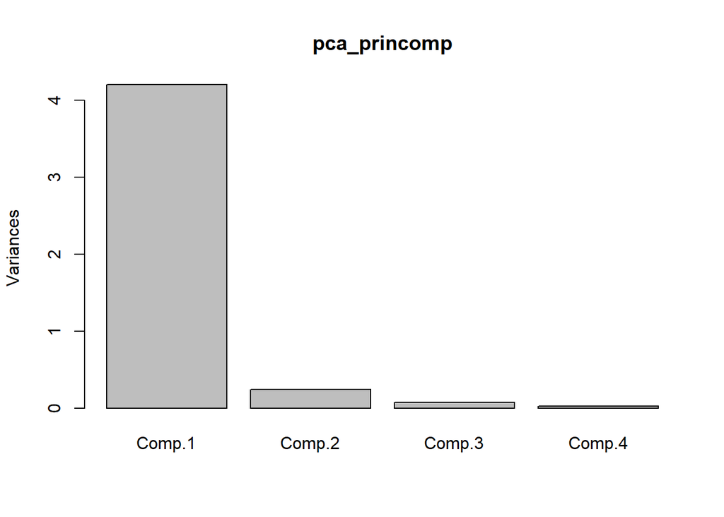

```r
plot(pca_princomp)
```

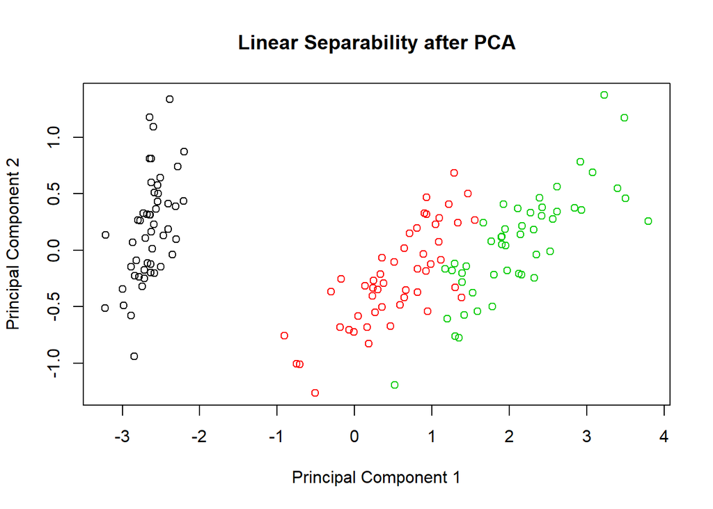

```r
iris_pca_data = data.frame(pca_princomp$scores, Species = iris_data$Species)

plot(iris_pca_data$Comp.1, iris_pca_data$Comp.2, col = iris_pca_data$Species, xlab = "Principal Component 1", ylab = "Principal Component 2",  main = "Linear Separability after PCA")
```

```r
reg_mod_3 = multinom(Species~., data = iris_pca_data )
pred_results_3 = reg_mod_3$fitted.values


actl_results_3 = iris_pca_data$Species


results_prcom = data.frame("pred_spec" = colnames(pred_results_3)[apply(pred_results_3,1,function(x) which(x==max(x)))],
                     "act_spec" = iris_pca_data$Species)

table(results_prcom)
```

```
##             act_spec
## pred_spec    setosa versicolor virginica
##   setosa         50          0         0
##   versicolor      0         49         1
##   virginica       0          1        49
```

Automated approach to implement the Principle components with scaling (as below).

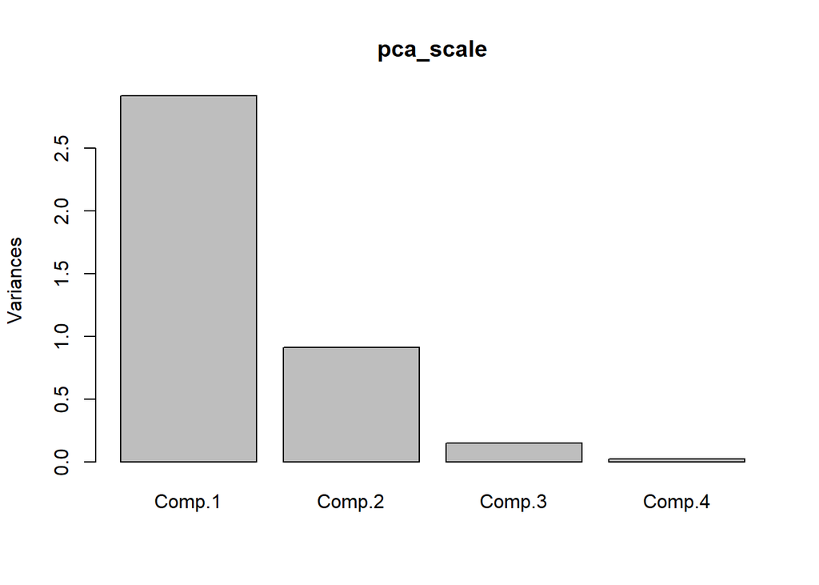

```r
pca_scale <- princomp(iris_data[,-c(5)],cor = T)

plot(pca_scale)
```

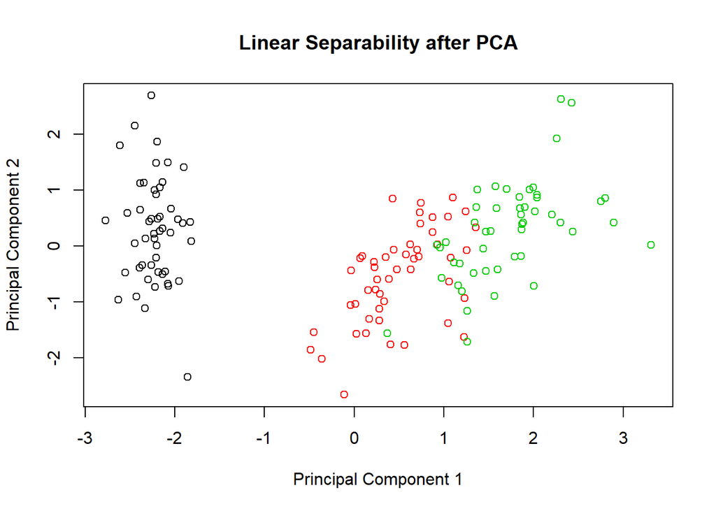

```r
iris_pca_Scale_data = data.frame(pca_scale$scores, Species = iris_data$Species)

plot(iris_pca_Scale_data$Comp.1, iris_pca_Scale_data$Comp.2, col = iris_pca_Scale_data$Species, xlab = "Principal Component 1", ylab = "Principal Component 2",  main = "Linear Separability after PCA")
```

```r
reg_mod_4 = multinom(Species~., data = iris_pca_Scale_data )
pred_results_4 = reg_mod_4$fitted.values


actl_results_4 = iris_pca_Scale_data$Species


results_prcom = data.frame("pred_spec" = colnames(pred_results_4)[apply(pred_results_4,1,function(x) which(x==max(x)))],
                     "act_spec" = iris_pca_Scale_data$Species)

table(results_prcom)
```

```
##             act_spec
## pred_spec    setosa versicolor virginica
##   setosa         50          0         0
##   versicolor      0         49         1
##   virginica       0          1        49
```

# Data Pre-processing

## Split the data into train and test

- 80/20 split of train and test

```r
set.seed(420)

train_rows <- sample(1:nrow(iris_data), 0.8*nrow(iris_data))

train_data <- iris_data[train_rows, ]

test_data <- iris_data[-train_rows, ]
```

# Automated Computation of Principal Components

## Sclaed PCA computation

```r
pca_scaled <- princomp(train_data[, !(names(train_data) %in% c("Species"))], cor = T)

head(pca_scaled$scores)
```

```
##         Comp.1     Comp.2     Comp.3      Comp.4
## 91   0.3873658 -1.1279099 -0.1462075 -0.27449674
## 145  1.9878569  1.1497618 -0.6232062  0.16882485
## 26  -1.8301597 -0.6951397  0.2901581  0.06185647
## 70   0.2888310 -1.3338783  0.1038648 -0.04820924
## 106  2.7643180  0.8397298  0.5622696 -0.10605418
## 128  1.0676118  0.1086322 -0.3540851 -0.03211240
```

```r
#pca_scaled <- prcomp(train_data[, !(names(train_data) %in% c("Species"))], center = T, scale. = T)

#head(pca_scaled$x)
```

- Plot the variance along each of the principal components
- We can now see that the dominance of the variance along the first principal component has reduced significantly

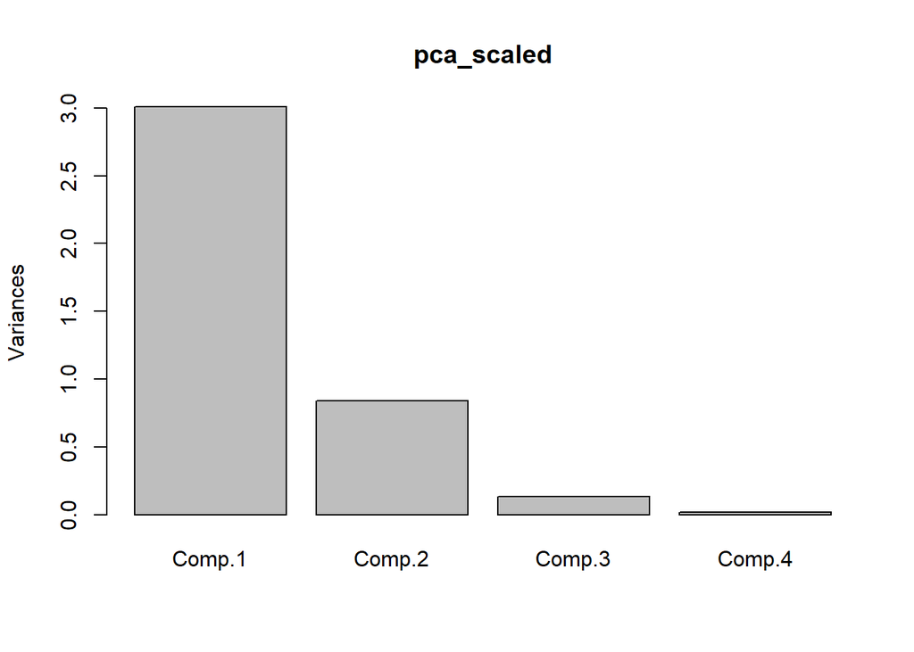

```r
plot(pca_scaled)
```

- Hence scaling the data before PCA, is extremely important as the higher range of one variable might unfairly influence the principal components

# Apply PCA on the Original Data

- Project the train and test data sets onto the derived principal components

```r
train_pca_e <- as.data.frame(predict(pca_scaled, train_data[, !(names(train_data) %in% c("Species"))]))

test_pca_e <- as.data.frame(predict(pca_scaled, test_data[, !(names(train_data) %in% c("Species"))]))
```